# Fraud Transactions Report

Author

Kolawole Ojo

Published

13 October 2026

# 1 Introduction

EssanPay Co. (EP) is a digital payment service provider that processes card payments and digital wallet transactions for e-commerce businesses. These businesses offer a wide range of products through multiple online merchants and retailers operating across several markets. Customers can conveniently make purchases through the retailers’ digital channels.

Although EP is experiencing rapid growth in online and mobile transactions, it faces a significant challenge: fraudulent transactions. While the company maintains records of these incidents, it does not yet have a clear understanding of the prevalence and distribution of fraud risks across its customer and merchant base.

The board has raised several questions to better understand the company’s exposure to transaction fraud and has engaged me as a consultant to analyse the available transaction data and provide evidence-based insights into its fraud exposure.

The following sections present insights from my data analysis that address the board’s questions.

# 2 Data overview

## 2.1 Variables and their values

This will give an indication of the level of variation in each variable. This also may provide insights that will guide the focus of the analysis.

Customer ID has 1092 unique values. It may generally not be useful to analyse this variable except for very specific purpose.

Table 1

| Items | Unique values |
| --- | --- |
| customer_id | 1,092 |
| merchant_category | 12 |
| billing_country | 10 |
| shipping_country | 10 |
| email_domain | 8 |
| channel | 4 |
| currency | 3 |
| product_type | 3 |
| payment_method | 3 |
| is_cross_border | 2 |

## 2.2 Missing values

The device_fingerprint has the highest number of missing values, followed by the merchant risk scores. We may not be able to input risk scores because they are externally determined.

Table 2

| Variables | Missing values |
| --- | --- |
| device_fingerprint | 185 |
| merchant_riskscore | 97 |
| email_domain | 41 |
| txn_count_1h | 19 |
| txn_count_24h | 12 |
| transaction_id | 0 |
| transaction_date | 0 |
| customer_id | 0 |
| customer_age | 0 |
| customer_tenure_days | 0 |
| is_vip | 0 |
| merchant_id | 0 |
| merchant_category | 0 |
| amount | 0 |
| currency | 0 |
| payment_method | 0 |
| channel | 0 |
| card_present | 0 |
| device_type | 0 |
| billing_country | 0 |
| shipping_country | 0 |
| ip_country | 0 |
| is_cross_border | 0 |
| is_new_device | 0 |
| prev_chargebacks_12m | 0 |
| product_type | 0 |
| actual_fraud | 0 |
| predicted_fraud | 0 |

# 3 Business Questions ————————————————————————–

In this section, I expored some business-related questions, provided evidence-based answers to them, and explained their implications for company’s business performance and decision-making.

## 3.1 Fraud rate and losses

### 3.1.1 Total fraudulent transaction

**What proportion of total transactions are fraudulent?**

The overall fraud rate for the month is about 2% of the total transaction. Though this varies vary by currency, with EUR recording the highest fraud rate at 1.5%, compared with GBP and USD.

EUR accounted for the majority of fraudulent transactions, with an average fraudulent transaction value of approximately EUR 60 . The total value of fraudulent transactions was approximately EUR 1,200, GBP 429, and USD 73 for EUR, GBP, and USD transactions, respectively.

Table 3

| Actual fraud | Count | Proportion |
| --- | --- | --- |
| Legitimate | 1,352 | 98% |
| Fraudulent | 25 | 2% |

### 3.1.2 Fraud incidence by currency

**Are there differences in total fraud rate and losses reported by currency?**

Table 4

| Fraud incidence by currency Currency | Fraud incidence by currency Fraud count | Fraud incidence by currency Total fraud loss | Fraud incidence by currency Average fraud loss | Fraud incidence by currency Fraud rate |
| --- | --- | --- | --- | --- |
| EUR | 20 | 1,183.28 | 59.2 | 1.5 |
| GBP | 4 | 428.74 | 107.2 | 0.3 |
| USD | 1 | 72.84 | 72.8 | 0.1 |

### 3.1.3 Daily fraud rate

**What is the daily fraud rate?**

One or two cases of fraud incidence per day are typical, with three cases on a single day being a peak-day occurence.

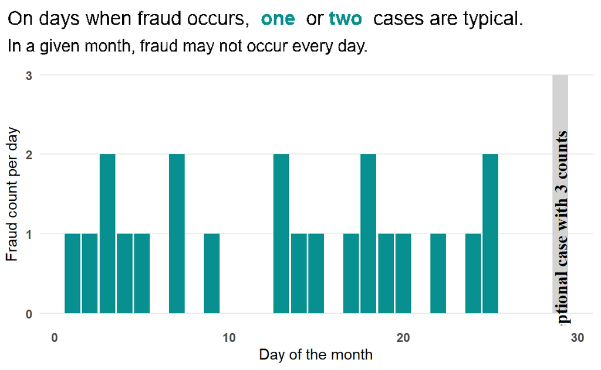

Figure 1

## 3.2 Customer risk analysis

### 3.2.1 Customer age and risk

**Which customer age groups have the highest incidence of fraud?**

Customer risk analysis: Fraud incidence does not appear to vary substantially by customer age. Customers across all age groups appear to be similarly likely to experience transaction fraud.

The three largest fraudulent transactions by transaction value involved card payments. However, further analysis is required to determine whether card payments are more susceptible to fraud than other payment methods.

Table 5

| Customer age | Fraud count |
| --- | --- |
| 26 | 2 |
| 42 | 2 |
| 19 | 1 |
| 21 | 1 |
| 24 | 1 |
| 25 | 1 |
| 28 | 1 |
| 34 | 1 |
| 36 | 1 |
| 41 | 1 |
| 49 | 1 |
| 54 | 1 |
| 55 | 1 |
| 56 | 1 |
| 59 | 1 |
| 62 | 1 |
| 64 | 1 |
| 65 | 1 |
| 68 | 1 |
| 73 | 1 |
| 77 | 1 |
| 78 | 1 |
| 79 | 1 |

### 3.2.2 Vip status and risk

**Are VIP customers more or less likely to experience fraud than non-VIP customers?**

No transactions involving VIP customers were identified as fraudulent; all fraudulent transactions involved non-VIP customers.

Table 6

| Vip status | currency | Fraud count | Total fraud loss |
| --- | --- | --- | --- |
| 0 | EUR | 20 | 1,183.28 |
| 0 | GBP | 4 | 428.74 |
| 0 | USD | 1 | 72.84 |

### 3.2.3 Customer tenure and risk

**Is customer tenure associated with a lower risk of fraud?**

Fraud incidence appears to vary by customer tenure. Customers with tenure below the average are more likely to have experienced fraud.

Specifically, 60% of the fraud cases were recorded by customers with shorter tenure, compared with 40% by those with longer tenure.

Table 7: Shorter tenure days are associated with higher fraud incidence

| Tenure category | Fraud count | Proportion |
| --- | --- | --- |
| Short tenure | 15 | 60% |
| Long tenure | 10 | 40% |

### 3.2.4 Customers exposure profile

**Which five customers experienced the highest fraud losses?**

It is also evident that the highest-value fraud involved card payments. Does this suggest that card payments are more susceptible to fraud?

Table 8: The single highest loss by a customer is EUR 216.80

| Customer ID | Customer age | Amount | Currency | Channel | Payment | Tenure |
| --- | --- | --- | --- | --- | --- | --- |
| C000804 | 24 | 216.80 | EUR | mobile_app | card | 3,378 |
| C000581 | 59 | 193.91 | GBP | web | card | 607 |
| C001866 | 77 | 118.64 | GBP | web | card | 1,620 |
| C001576 | 42 | 118.49 | EUR | pos | card | 671 |
| C001779 | 54 | 103.16 | EUR | web | card | 772 |

## 3.3 Digital properties and fraud incidence:

### 3.3.1 Payment methods and risk

**Which payment methods have the highest incidence of fraud?**

Card payment transactions recorded the highest fraud count.

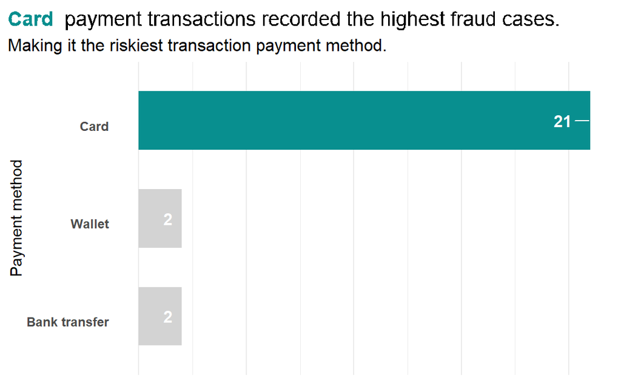

Figure 2

### 3.3.2 Transactions channels risk

**Which transactions channels have the highest fraud rates?** Web channel transations reported the highest fraud.

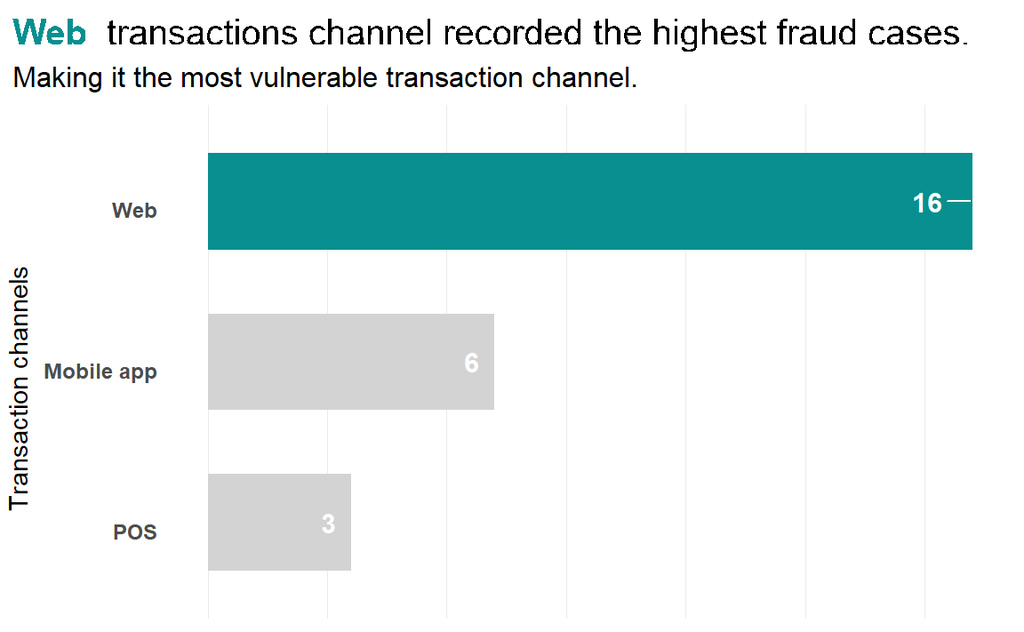

Figure 3

## 3.4 Geographic locations and fraud patterns

### 3.4.1 Cross-border transactions and fraud patterns

**Are cross-border transactions riskier?**

To answer this question, I first defined what cross-border transactions are and then analysed transactions that meet the criteria. I defined them as those where the customer’s ip_country, billing_country, and shipping_country differ.

The majority of fraudulent transactions (88%) are cross-border transactions. These are transactions in which the IP country differs from the billing country and the billing country differs from the shipping country.

Table 9: Majority of fradulent transactions are cross border

| Status | Nature | Fraud count | Prop. |
| --- | --- | --- | --- |
| Fraudulent | cross border | 22 | 88% |
| Fraudulent | within border | 3 | 12% |

### 3.4.2 Billing destination and risk

**Which are the top billing countries for fraudulent transaction?**

Great Britain and Ireland are the billing destinations with highest fraud incidence.

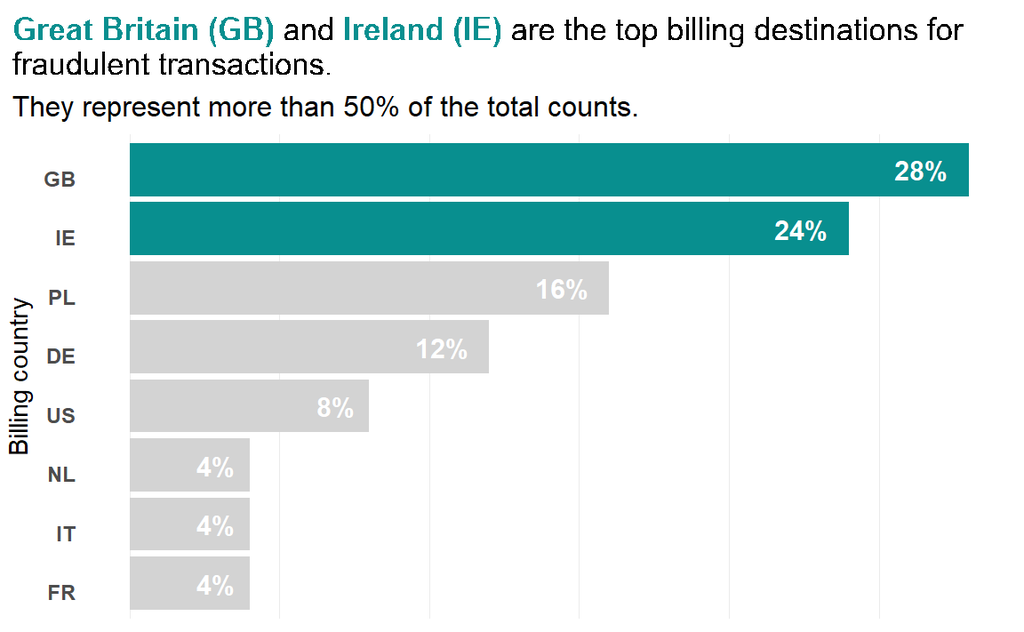

Figure 4

## 3.5 Merchant risk analyses

### 3.5.1 Fraud incidence and merchant risk

**Does fraud incidence vary by merchant risk score?**

Fraudulent transactions are common with high-risk merchants relative to non-fraudulent ones than their low-risk counter parts.

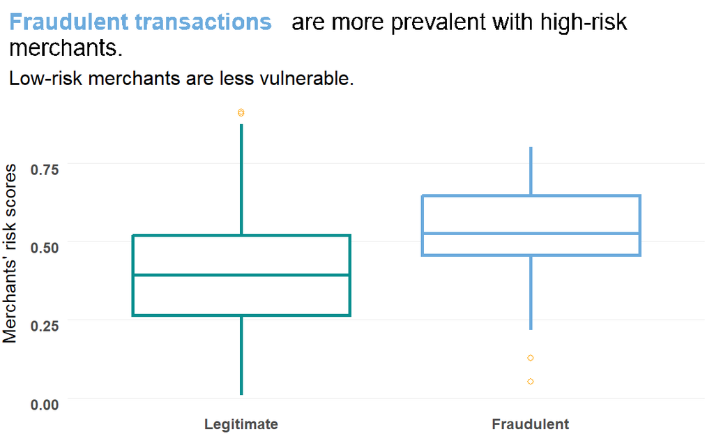

Figure 5

### 3.5.2 Merchant categories and risk

**Which merchant categories have the highest fraud rates?**

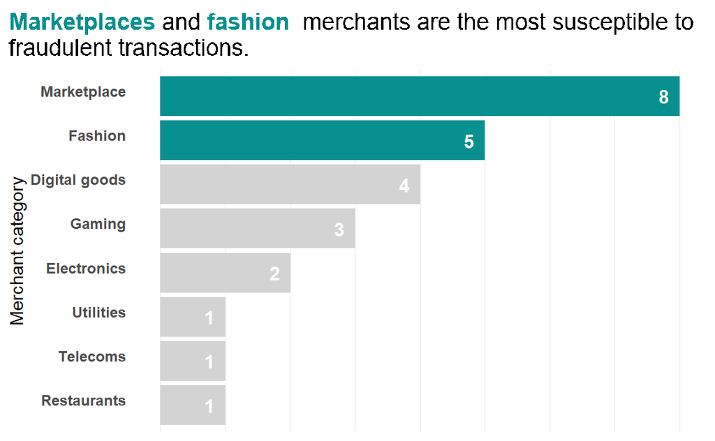

Figure 6

# 4 Conclusions